# Weighted genome-wide analysis

# Project setup

## Project folder

- Create project folder and set up the folder structure as follows:

```bash
    # Define project directory
    PFOLDER="your/project"

    # Create subfolders
    mkdir $PFOLDER/programs
    mkdir $PFOLDER/data
    mkdir $PFOLDER/output
```

- Folder structure:

```bash
PFOLDER/
   | wGWA.R
   ├── data/
   │   └── GenData.bed
   │   └── GenData.bim
   │   └── GenData.fam
   │   └── phenoDat
   ├── output/
   ├── programs/
       └── ldak
```

## Download the toy data

1. [Download here](https://www.dropbox.com/sh/adhqkz2w1wxf9it/AABND7yvYr9IH7CyrGt3Rg_ta?dl=0)
2. store data in `$PFOLDER`

## Download LDAK

1. [Download here](http://www.ldak.org/downloads/)
2. Rename and store LDAK as follows: `$PFOLDER/programs/ldak`

## Dowload the R script to perform all analyses

1. [Download here](https://www.dropbox.com/sh/adhqkz2w1wxf9it/AABND7yvYr9IH7CyrGt3Rg_ta?dl=0)
2. Store R-script as follows: `$PFOLDER/wGWA.R`

## Application of sampling weights to phenotypic data

- Load R-packages and define working directory

```r
if (!require("hudson")) install.packages("hudson")
if (!require("data.table")) install.packages("data.table")
PFOLDER="your/project"
```

- Load functions

```r
# =========== FUNCTIONS ==========================
# get weighted mean
meanW=function(df, pheno){
  weights=df$weights
  variable=df[[pheno]]
  meanW=sum(variable*weights)/sum(weights)
  mean=mean(variable, na.rm=T)
  return(data.frame(pheno=pheno, meanS=round(mean,1), meanW=round(meanW,1)))
}


# get weighted and standard correlations
get_lower_tri<-function(cormat){
  cormat[upper.tri(cormat)] <- NA
  return(cormat)
}

getWcor=function(df, pheno){
  weighted_corr <- cov.wt(subset(df, select=c(pheno)), wt = df$weights, cor = TRUE)
  corr_matrix <- weighted_corr$cor
  cor_w_tri <- get_lower_tri(corr_matrix)
  corMelt_w=melt(cor_w_tri)
  corOutW=subset(corMelt_w, Var1!=Var2 & is.na(value)==F )

  cor_sample=cor(subset(df, select=c(pheno)))
  cor_tri <- get_lower_tri(cor_sample)
  corMelt=melt(cor_tri)
  corOut=subset(corMelt, Var1!=Var2 & is.na(value)==F )

  corDF=data.frame(cor=paste0(corOut$Var1, "~", corOut$Var2), corS=corOut$value, corW=corOutW$value)
  return(corDF)
}
```

# Phenotype analyses

### Read in phenotype data

```r
dat=fread(paste0(PFOLDER, "/data/PhenoDat"))
head(dat)
```

| FID | IID | age | bmi | education | weights |
| --- | --- | --- | --- | --- | --- |
| FAM0001 | IID0001 | 56.42 | 25.91 | 17.60 | 0.51 |
| FAM0001 | IID0002 | 50.17 | 21.66 | 20.16 | 0.10 |
| FAM0001 | IID0003 | 41.63 | 38.89 | 14.57 | 20.44 |
| FAM0001 | IID0004 | 55.46 | 29.34 | 19.52 | 0.30 |

- The sampling weight are stored in the column `dat$weights`
- The sampling weights were designed to bring the non-representative (simulated) sample in line with a (simulated) representative reference sample. We have the following means in the simulated datasets:

| Phenotype | Mean in reference sample | Mean in non-representative sample |
| --- | --- | --- |
| age | 53.0 | 57.0 |
| bmi | 28.0 | 26.5 |
| education | 16.5 | 17.5 |

- The estimated weights were re-scaled so that they sum up to the total sample, where a re-scaled weight >1 means that an individual carries more weight in the weighted population than in the original population, and a re-scaled weight <1 means that an individual carries less weight.

### Spread of the sampling weights

```r
summary(dat$weights)
```

Sampling weights

| mean | min | max |
| --- | --- | --- |
| 1 | 0.01 | 36.19 |

### The effective sample size of the weighted sample

The effective sample size (nEFF) for the weighed sample is calculated using the formula:

$$\textrm{nEFF} = \frac{(\sum_{i=1}^n
w_i)^2}{\sum_{i=1}^n w_i^2}$$

```r
nEFF=round((sum(dat$weights)^2)/sum(dat$weights^2),0)
```

| Sample size |
| --- |
| Total sample size: 6000 |
| Effective sample size: 1684 |

### Estimate weighted mean

$$Weighted Mean =
\frac{1}{N}\sum_{i=1}^{N}w_i x_i$$

```r
pheno=c("age", "bmi", "education")
outWL=lapply(pheno, function(x) meanW(df=dat, pheno=x))
outW=do.call(rbind, outWL)
```

| Phenotye | mean (non-representative sample) | mean (weighted sample) | mean (reference sample) |
| --- | --- | --- | --- |
| age | 56.9 | 53.1 | 53.0 |
| bmi | 26.3 | 28.3 | 28.0 |
| education | 17.5 | 16.2 | 16.5 |

### Estimate weighted correlations

```r
corW=getWcor(df=dat, pheno=pheno)
```

|  | Correlation (non-representive sample) | Correlation (weighted sample) | Correlation (reference sample) |
| --- | --- | --- | --- |
| bmi~age | 0.1 | 0.24 | 0.3 |
| education~age | 0.1 | 0.24 | 0.3 |
| education~bmi | 0.1 | 0.17 | 0.3 |

The following correlations were used to simulate the data:

- Correlations among all phenotypes in the non-representative sample: $r=0.1$
- Correlations among all phenotypes in the reference sample: $r=0.3$

# Genotype analyses

## Weighted genome-wide analyses

### Prepare data for LDAK

**Phenotype data**

```r
# prepare phenotype data
write.table(subset(dat, select=c(FID, IID, bmi)),
            file= paste0(PFOLDER, "/output/phenoLDAK" ),
            sep="\t",
            row.names = F,
            col.names=F,
            quote=F)

print(head(subset(dat, select=c(FID, IID, bmi)), n=3))
```

```
##        FID     IID      bmi
## 1: FAM0001 IID0001 25.91042
## 2: FAM0001 IID0002 21.66125
## 3: FAM0001 IID0003 38.89009
```

**Sampling weights**

```r
write.table(subset(dat, select=c(FID, IID, weights)),
            file= paste0(PFOLDER, "/output/weightsLDAK" ),
            sep="\t",
            row.names = F,
            col.names=F,
            quote=F)

print(head(subset(dat, select=c(FID, IID, weights)), n=3))
```

```
##        FID     IID     weights
## 1: FAM0001 IID0001  0.50752976
## 2: FAM0001 IID0002  0.09965894
## 3: FAM0001 IID0003 20.44120488
```

### Run standard GWA in LDAK

- A detailed documentation is available on the LDAK [website](https://dougspeed.com/single-predictor-analysis/)
- Parameters standard linear regression:
  - `--linear <outfile>`: perform linear regression
  - `--pheno <phenofile>`: to specify the phenotypes (in PLINK format)
  - `--covar <covarfile>`: to provide covariates (in PLINK format)
  - `--bfile`: to specify the genetic data files

```r
# give execute permissions
system(paste0("chmod a+x ",PFOLDER, "/programs/ldak"))
# run linear regression
start_time <- Sys.time()
system(paste0(PFOLDER, "/programs/ldak --linear ",  PFOLDER, "/output/bmi --pheno ", PFOLDER, "/output/phenoLDAK --bfile ",PFOLDER, "/data/GenData"))
end_time <- Sys.time()
```

```
## [1] "Running time standard GWAS: 1.5 seconds"
```

**Results**

- The main results are saved in `bmi.assoc`
- The a summary version of the results is saved in `bmi.summaries`
- The p-values are saved in `bmi.pvalues`

### Run weighted GWA in LDAK

- To run weighted linear regression, set:
  - `--sandwich YES`: use sandwich estimator to get the standard errors (Huber-White Sandwich Estimator)
  - `--sample-weights <sampleweightfile>`: perform weighted linear regression. The `<sampleweightfile>` should have three columns, where each row provides two sample IDs followed by the sampling weights

```r
# run LDAK
start_time <- Sys.time()
system(paste0(PFOLDER, "/programs/ldak --linear ",  PFOLDER, "/output/bmiW --pheno ", PFOLDER, "/output/phenoLDAK --sandwich YES --sample-weights ", PFOLDER, "/output/weightsLDAK --bfile ",PFOLDER, "/data/GenData"))
end_time <- Sys.time()
```

```
## [1] "Running time weighted GWAS: 1.78 seconds"
```

**Results**

- The main results are saved in `bmiW.assoc`
- The a summary version of the results is saved in `bmiW.summaries`
- The p-values are saved in `bmiW.pvalues`

### Process LDAK output

```r
list.files(paste0(PFOLDER, "/output"))
```

```
##  [1] "bmi.assoc"      "bmi.coeff"      "bmi.progress"   "bmi.pvalues"
##  [5] "bmi.score"      "bmi.summaries"  "bmiW.assoc"     "bmiW.coeff"
##  [9] "bmiW.progress"  "bmiW.pvalues"   "bmiW.score"     "bmiW.summaries"
## [13] "phenoLDAK"      "weightsLDAK"
```

```r
# Weighted GWA
effectW=fread(paste0(PFOLDER, "/output/bmiW.assoc"), header=T)
gwaW=data.frame(SNP=effectW$Predictor, CHR=effectW$Chromosome, POS=effectW$Basepair, BETA=effectW$Effect, SE=effectW$SD)
pvalw=fread(paste0(PFOLDER, "/output/bmiW.pvalues"), header=T)
gwaW$pvalue=pvalw$P
```

Weighted estimates

| SNP | CHR | POS | BETA | SE | pvalue |
| --- | --- | --- | --- | --- | --- |
| rs0001 | 1 | 10090 | 0.00 | 0.19 | 0.98 |
| rs0002 | 1 | 10133 | 0.01 | 0.19 | 0.97 |
| rs0003 | 1 | 10247 | -0.22 | 0.33 | 0.51 |

```r
effect=fread(paste0(PFOLDER, "/output/bmi.assoc"), header=T)
gwa=data.frame(SNP=effect$Predictor, CHR=effect$Chromosome, POS=effect$Basepair, BETA=effect$Effect, SE=effect$SD)
pval=fread(paste0(PFOLDER, "/output/bmi.pvalues"), header=T)
gwa$pvalue=pval$P
```

Standard estimates

| SNP | CHR | POS | BETA | SE | pvalue |
| --- | --- | --- | --- | --- | --- |
| rs0001 | 1 | 10090 | 0.09 | 0.09 | 0.35 |
| rs0002 | 1 | 10133 | 0.09 | 0.09 | 0.35 |
| rs0003 | 1 | 10247 | -0.14 | 0.14 | 0.32 |

### Plot the results

```r
setwd(paste0(PFOLDER))
manH=gmirror(top=subset(gwa, select=c(SNP, CHR, POS, pvalue)),
             bottom=subset(gwaW, select=c(SNP, CHR, POS, pvalue)), tline=0.05, bline=0.05,
             toptitle="Standard GWAS",
             bottomtitle = "Weighted GWAS",
             highlight_p = c(0.05,0.05),
             highlighter="darkviolet",
             file="/output/ManH")
```

```
## [1] "Saving plot to /output/ManH.png"
```

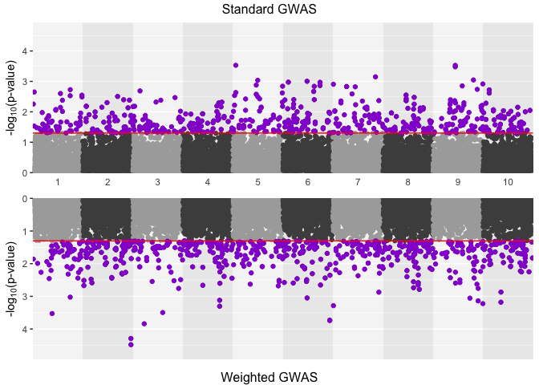